# Lab 4 - Multi-Layer Perceptron

- Ayesh Madushanka Mahamada Kalapuwage
- Bárbara Maria Teixeira Costa Peluzo

```python
import pandas as pd
import missingno as mn
import numpy as np
from matplotlib import pyplot as plt
from sklearn.model_selection import train_test_split
from scipy.special import expit
import sys
from sklearn.metrics import accuracy_score
import warnings
import copy
warnings.simplefilter(action='ignore', category=UserWarning)
plt.style.use('ggplot')
```

Data description: https://www.kaggle.com/muonneutrino/us-census-demographic-data/data

### Load, Split, and Balance

Load the data into memory and save it to a pandas data frame. Do not normalize or one-hot encode any of the features until asked to do so. Remove any observations that having missing data. Encode any string data as integers for now.

```python
df=pd.read_csv('acs2017_census_tract_data.csv')
df.head()
```

|  | TractId | State | County | TotalPop | Men | Women | Hispanic | White | Black | Native | ... | Walk | OtherTransp | WorkAtHome | MeanCommute | Employed | PrivateWork | PublicWork | SelfEmployed | FamilyWork | Unemployment |
| --- | --- | --- | --- | --- | --- | --- | --- | --- | --- | --- | --- | --- | --- | --- | --- | --- | --- | --- | --- | --- | --- |
| 0 | 1001020100 | Alabama | Autauga County | 1845 | 899 | 946 | 2.4 | 86.3 | 5.2 | 0.0 | ... | 0.5 | 0.0 | 2.1 | 24.5 | 881 | 74.2 | 21.2 | 4.5 | 0.0 | 4.6 |
| 1 | 1001020200 | Alabama | Autauga County | 2172 | 1167 | 1005 | 1.1 | 41.6 | 54.5 | 0.0 | ... | 0.0 | 0.5 | 0.0 | 22.2 | 852 | 75.9 | 15.0 | 9.0 | 0.0 | 3.4 |
| 2 | 1001020300 | Alabama | Autauga County | 3385 | 1533 | 1852 | 8.0 | 61.4 | 26.5 | 0.6 | ... | 1.0 | 0.8 | 1.5 | 23.1 | 1482 | 73.3 | 21.1 | 4.8 | 0.7 | 4.7 |
| 3 | 1001020400 | Alabama | Autauga County | 4267 | 2001 | 2266 | 9.6 | 80.3 | 7.1 | 0.5 | ... | 1.5 | 2.9 | 2.1 | 25.9 | 1849 | 75.8 | 19.7 | 4.5 | 0.0 | 6.1 |
| 4 | 1001020500 | Alabama | Autauga County | 9965 | 5054 | 4911 | 0.9 | 77.5 | 16.4 | 0.0 | ... | 0.8 | 0.3 | 0.7 | 21.0 | 4787 | 71.4 | 24.1 | 4.5 | 0.0 | 2.3 |

5 rows × 37 columns

First of all, let's check for any missing data and remove such observations:

```python
df.isnull().sum()
```

```
TractId                0
State                  0
County                 0
TotalPop               0
Men                    0
Women                  0
Hispanic             696
White                696
Black                696
Native               696
Asian                696
Pacific              696
VotingAgeCitizen       0
Income              1116
IncomeErr           1116
IncomePerCap         745
IncomePerCapErr      745
Poverty              842
ChildPoverty        1110
Professional         811
Service              811
Office               811
Construction         811
Production           811
Drive                801
Carpool              801
Transit              801
Walk                 801
OtherTransp          801
WorkAtHome           801
MeanCommute          946
Employed               0
PrivateWork          811
PublicWork           811
SelfEmployed         811
FamilyWork           811
Unemployment         810
dtype: int64
```

```python
df=df.dropna(axis=0,how='any')
```

```python
df.isnull().sum()
```

```
TractId             0
State               0
County              0
TotalPop            0
Men                 0
Women               0
Hispanic            0
White               0
Black               0
Native              0
Asian               0
Pacific             0
VotingAgeCitizen    0
Income              0
IncomeErr           0
IncomePerCap        0
IncomePerCapErr     0
Poverty             0
ChildPoverty        0
Professional        0
Service             0
Office              0
Construction        0
Production          0
Drive               0
Carpool             0
Transit             0
Walk                0
OtherTransp         0
WorkAtHome          0
MeanCommute         0
Employed            0
PrivateWork         0
PublicWork          0
SelfEmployed        0
FamilyWork          0
Unemployment        0
dtype: int64
```

```python
df.head()
```

|  | TractId | State | County | TotalPop | Men | Women | Hispanic | White | Black | Native | ... | Walk | OtherTransp | WorkAtHome | MeanCommute | Employed | PrivateWork | PublicWork | SelfEmployed | FamilyWork | Unemployment |
| --- | --- | --- | --- | --- | --- | --- | --- | --- | --- | --- | --- | --- | --- | --- | --- | --- | --- | --- | --- | --- | --- |
| 0 | 1001020100 | Alabama | Autauga County | 1845 | 899 | 946 | 2.4 | 86.3 | 5.2 | 0.0 | ... | 0.5 | 0.0 | 2.1 | 24.5 | 881 | 74.2 | 21.2 | 4.5 | 0.0 | 4.6 |
| 1 | 1001020200 | Alabama | Autauga County | 2172 | 1167 | 1005 | 1.1 | 41.6 | 54.5 | 0.0 | ... | 0.0 | 0.5 | 0.0 | 22.2 | 852 | 75.9 | 15.0 | 9.0 | 0.0 | 3.4 |
| 2 | 1001020300 | Alabama | Autauga County | 3385 | 1533 | 1852 | 8.0 | 61.4 | 26.5 | 0.6 | ... | 1.0 | 0.8 | 1.5 | 23.1 | 1482 | 73.3 | 21.1 | 4.8 | 0.7 | 4.7 |
| 3 | 1001020400 | Alabama | Autauga County | 4267 | 2001 | 2266 | 9.6 | 80.3 | 7.1 | 0.5 | ... | 1.5 | 2.9 | 2.1 | 25.9 | 1849 | 75.8 | 19.7 | 4.5 | 0.0 | 6.1 |
| 4 | 1001020500 | Alabama | Autauga County | 9965 | 5054 | 4911 | 0.9 | 77.5 | 16.4 | 0.0 | ... | 0.8 | 0.3 | 0.7 | 21.0 | 4787 | 71.4 | 24.1 | 4.5 | 0.0 | 2.3 |

5 rows × 37 columns

We will now look at the data types and encode any string data as integers:

```python
df.dtypes
```

```
TractId               int64
State                object
County               object
TotalPop              int64
Men                   int64
Women                 int64
Hispanic            float64
White               float64
Black               float64
Native              float64
Asian               float64
Pacific             float64
VotingAgeCitizen      int64
Income              float64
IncomeErr           float64
IncomePerCap        float64
IncomePerCapErr     float64
Poverty             float64
ChildPoverty        float64
Professional        float64
Service             float64
Office              float64
Construction        float64
Production          float64
Drive               float64
Carpool             float64
Transit             float64
Walk                float64
OtherTransp         float64
WorkAtHome          float64
MeanCommute         float64
Employed              int64
PrivateWork         float64
PublicWork          float64
SelfEmployed        float64
FamilyWork          float64
Unemployment        float64
dtype: object
```

String data are presented in the atribbutes: **State** and **County**. We will convert the State entries as integers. With respect to the County entry, we will drop it. We are also not interested in the TrackId, so we will delete it as well.

```python
df.State.replace(to_replace=df.State.unique()[:],
                  value=range(df.State.unique().size),
                  inplace=True)
del df['County']
del df['TractId']
```

```python
df.dtypes
```

```
State                 int64
TotalPop              int64
Men                   int64
Women                 int64
Hispanic            float64
White               float64
Black               float64
Native              float64
Asian               float64
Pacific             float64
VotingAgeCitizen      int64
Income              float64
IncomeErr           float64
IncomePerCap        float64
IncomePerCapErr     float64
Poverty             float64
ChildPoverty        float64
Professional        float64
Service             float64
Office              float64
Construction        float64
Production          float64
Drive               float64
Carpool             float64
Transit             float64
Walk                float64
OtherTransp         float64
WorkAtHome          float64
MeanCommute         float64
Employed              int64
PrivateWork         float64
PublicWork          float64
SelfEmployed        float64
FamilyWork          float64
Unemployment        float64
dtype: object
```

Assume you are equally interested in the classification performance for each class in the dataset. Split the dataset into 80% for training and 20% for testing.

Balance the dataset so that about the same number of instances are within each class. Choose a method for balancing the dataset and explain your reasoning for selecting this method. One option is to choose quantization thresholds for the "ChildPoverty" variable that equally divide the data into four classes. *Should balancing of the dataset be done for both the training and testing set? Explain*

Let's take a look on how our data are distributed:

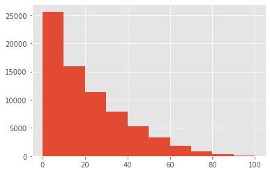

```python
plt.hist(df.ChildPoverty)
```

The data is not uniformly distributed, thus we cannot use 0-25; 26-50; 51-75; 76-100. Instead of that, we can use the quartiles, which automaticaly divide the data into 4 groups of the same size:

```python
quart=pd.qcut(df.ChildPoverty,q=4,labels=range(4))
print(quart)
```

```
0        2
1        3
2        2
3        0
4        2
        ..
73996    3
73997    3
73998    3
73999    3
74000    3
Name: ChildPoverty, Length: 72718, dtype: category
Categories (4, int64): [0 < 1 < 2 < 3]
```

```python
y=quart.to_numpy()
del df['ChildPoverty']
X=df.to_numpy()
X_train, X_test, y_train, y_test = train_test_split(X,y,test_size = 0.2)
print(X_train.shape)
print(y_train.shape)
print(X_test.shape)
print(y_test.shape)
```

```
(58174, 34)
(58174,)
(14544, 34)
(14544,)
```

Both training and test splits are equally balanced. That balancing must be done for both sets, once they must be similar in data, differing only on the size. The training set should reproduce our testing, otherwise the training would not be effective.

### Pre-processing

There are a number of version of the two layer perceptron covered in class. When using the example two layer network from class be sure that you use: (1) vectorized computation, (2) mini-batching, and (3) proper Glorot initialization, at a minimum.

```python
class TwoLayerPerceptronBase(object):
    def __init__(self, n_hidden=30,
                 C=0.0, epochs=500, eta=0.001, random_state=None):
        np.random.seed(random_state)
        self.n_hidden = n_hidden
        self.l2_C = C
        self.epochs = epochs
        self.eta = eta

    @staticmethod
    def _encode_labels(y):
        """Encode labels into one-hot representation"""
        onehot = pd.get_dummies(y).values.T

        return onehot

    def _initialize_weights(self):
        """Initialize weights with small random numbers."""
        W1_num_elems = (self.n_features_ + 1)*self.n_hidden
        W1 = np.random.uniform(-1.0, 1.0,size=W1_num_elems)
        W1 = W1.reshape(self.n_hidden, self.n_features_ + 1) # reshape to be W

        W2_num_elems = (self.n_hidden + 1)*self.n_output_
        W2 = np.random.uniform(-1.0, 1.0, size=W2_num_elems)
        W2 = W2.reshape(self.n_output_, self.n_hidden + 1)
        return W1, W2

    @staticmethod
    def _sigmoid(z):
        """Use scipy.special.expit to avoid overflow"""
        # 1.0 / (1.0 + np.exp(-z))
        return expit(z)

    @staticmethod
    def _add_bias_unit(X, how='column'):
        """Add bias unit (column or row of 1s) to array at index 0"""
        if how == 'column':
            ones = np.ones((X.shape[0], 1))
            X_new = np.hstack((ones, X))
        elif how == 'row':
            ones = np.ones((1, X.shape[1]))
            X_new = np.vstack((ones, X))
        return X_new

    @staticmethod
    def _L2_reg(lambda_, W1, W2):
        """Compute L2-regularization cost"""
        # only compute for non-bias terms
        return (lambda_/2.0) * np.sqrt(np.mean(W1[:, 1:] ** 2) + np.mean(W2[:, 1:] ** 2))

    def _cost(self,A3,Y_enc,W1,W2):
        '''Get the objective function value'''
        cost = np.mean((Y_enc-A3)**2)
        L2_term = self._L2_reg(self.l2_C, W1, W2)
        return cost + L2_term

    def _feedforward(self, X, W1, W2):
        """Compute feedforward step
        """
        A1 = self._add_bias_unit(X, how='column')
        A1 = A1.T
        Z1 = W1 @ A1
        A2 = self._sigmoid(Z1)
        A2 = self._add_bias_unit(A2, how='row')
        Z2 = W2 @ A2
        A3 = self._sigmoid(Z2)
        return A1, Z1, A2, Z2, A3

    def _get_gradient(self, A1, A2, A3, Z1, Z2, Y_enc, W1, W2):
        """ Compute gradient step using backpropagation.
        """
        # vectorized backpropagation
        V2 = -2*(Y_enc-A3)*A3*(1-A3)  # last layer sensitivity
        V1 = A2*(1-A2)*(W2.T @ V2) # back prop the sensitivity

        grad2 = V2 @ A2.T # no bias on final layer
        grad1 = V1[1:,:] @ A1.T # dont back prop sensitivity of bias


        # regularize weights that are not bias terms
        grad1[:, 1:] += W1[:, 1:] * self.l2_C
        grad2[:, 1:] += W2[:, 1:] * self.l2_C

        return grad1, grad2

    def predict(self, X):
        """Predict class labels"""
        _, _, _, _, A3 = self._feedforward(X, self.W1, self.W2)
        y_pred = np.argmax(A3, axis=0)
        return y_pred
```

```python
class TLPMiniBatch(TwoLayerPerceptronBase):
    def __init__(self, alpha=0.0, decrease_const=0.0, shuffle=True,
                 minibatches=1, **kwds):
        # need to add to the original initializer
        self.alpha = alpha
        self.decrease_const = decrease_const
        self.shuffle = shuffle
        self.minibatches = minibatches
        # but keep other keywords
        super().__init__(**kwds)


    def fit(self, X, y, print_progress=False, XY_test=None):
        """ Learn weights from training data. With mini-batch"""
        X_data, y_data = X.copy(), y.copy()
        Y_enc = self._encode_labels(y)

        # init weights and setup matrices
        self.n_features_ = X_data.shape[1]
        self.n_output_ = Y_enc.shape[0]
        self.W1, self.W2 = self._initialize_weights()

        rho_W1_prev = np.zeros(self.W1.shape)
        rho_W2_prev = np.zeros(self.W2.shape)

        self.cost_ = []
        self.score_ = []
        # get starting acc
        self.score_.append(accuracy_score(y_data,self.predict(X_data)))
        # keep track of validation, if given
        if XY_test is not None:
            X_test = XY_test[0].copy()
            y_test = XY_test[1].copy()
            self.val_score_ = []
            self.val_score_.append(accuracy_score(y_test,self.predict(X_test)))

        for i in range(self.epochs):

            # adaptive learning rate
            # \frac{\eta}{1+\epsilon\cdot k}
            eta = self.eta / (1 + self.decrease_const*i)

            if print_progress>0 and (i+1)%print_progress==0:
                sys.stderr.write('\rEpoch: %d/%d' % (i+1, self.epochs))
                sys.stderr.flush()

            if self.shuffle:
                idx_shuffle = np.random.permutation(y_data.shape[0])
                X_data, Y_enc, y_data = X_data[idx_shuffle], Y_enc[:, idx_shuffle], y_data[idx_shuffle]

            mini = np.array_split(range(y_data.shape[0]), self.minibatches)
            mini_cost = []
            for idx in mini:

                # feedforward
                A1, Z1, A2, Z2, A3 = self._feedforward(X_data[idx],
                                                       self.W1,
                                                       self.W2)

                cost = self._cost(A3,Y_enc[:, idx],self.W1,self.W2)
                mini_cost.append(cost) # this appends cost of mini-batch only

                # compute gradient via backpropagation
                grad1, grad2 = self._get_gradient(A1=A1, A2=A2, A3=A3, Z1=Z1, Z2=Z2,
                                                  Y_enc=Y_enc[:, idx],
                                                  W1=self.W1,W2=self.W2)

                # momentum calculations
                rho_W1, rho_W2 = eta * grad1, eta * grad2
                self.W1 -= (rho_W1 + (self.alpha * rho_W1_prev))
                self.W2 -= (rho_W2 + (self.alpha * rho_W2_prev))
                rho_W1_prev, rho_W2_prev = rho_W1, rho_W2

            self.cost_.append(mini_cost)
            self.score_.append(accuracy_score(y_data,self.predict(X_data)))
            if XY_test is not None:
                self.val_score_.append(accuracy_score(y_test,self.predict(X_test)))

        return self
```

```python
class TLPMiniBatchCrossEntropy(TLPMiniBatch):
    def _cost(self,A3,Y_enc,W1,W2):
        '''Get the objective function value'''
        cost = -np.mean(np.nan_to_num((Y_enc*np.log(A3)+(1-Y_enc)*np.log(1-A3))))
        L2_term = self._L2_reg(self.l2_C, W1, W2)
        return cost + L2_term

    def _get_gradient(self, A1, A2, A3, Z1, Z2, Y_enc, W1, W2):
        """ Compute gradient step using backpropagation.
        """
        # vectorized backpropagation
        V2 = (A3-Y_enc) # <- this is only line that changed
        V1 = A2*(1-A2)*(W2.T @ V2)

        grad2 = V2 @ A2.T
        grad1 = V1[1:,:] @ A1.T

        # regularize weights that are not bias terms
        grad1[:, 1:] += W1[:, 1:] * self.l2_C
        grad2[:, 1:] += W2[:, 1:] * self.l2_C

        return grad1, grad2
```

```python
class TLPBetterInitial(TLPMiniBatchCrossEntropy):
    def _initialize_weights(self):
        """Initialize weights Glorot and He normalization."""
        init_bound = 4*np.sqrt(6. / (self.n_hidden + self.n_features_ + 1))
        W1 = np.random.uniform(-init_bound, init_bound,(self.n_hidden, self.n_features_ + 1))
        W1[:,:1] = 0

        # reduce the final layer magnitude in order to balance the size of the gradients
        # between
        init_bound = 4*np.sqrt(6 / (self.n_output_ + self.n_hidden + 1))
        W2 = np.random.uniform(-init_bound, init_bound,(self.n_output_, self.n_hidden + 1))
        W2[:,:1] = 0

        return W1, W2
```

Use the example two-layer perceptron network from the class example and quantify performance using accuracy. Do not normalize or one-hot encode the data (not yet). Be sure that training converges by graphing the loss function versus the number of epochs.

```python
def print_result(nn,X_train,y_train,X_test,y_test,title="",color="red"):

    print("=================")
    print(title,":")
    yhat = nn.predict(X_train)
    print('Resubstitution acc:',accuracy_score(y_train,yhat))

    yhat = nn.predict(X_test)
    print('Validation acc:',accuracy_score(y_test,yhat))

    if hasattr(nn,'val_score_'):
        plt.plot(range(len(nn.val_score_)), nn.val_score_, color=color,label=title)
        plt.ylabel('Validation Accuracy')
    else:
        plt.plot(range(len(nn.score_)), nn.score_, color=color,label=title)
        plt.ylabel('Resub Accuracy')

    plt.xlabel('Epochs')
    plt.tight_layout()
    plt.legend(loc='best')
    plt.grid(True)
```

```python
vals = { 'n_hidden':30,
         'C':0.1, 'epochs':100, 'eta':0.001,
         'alpha':0.001, 'decrease_const':1e-5, 'minibatches':50,
         'shuffle':True,'random_state':1}
```

```python
vals['epochs']=70

nn = TLPBetterInitial(**vals)

nn.fit(X_train, y_train, print_progress=1, XY_test=(X_test, y_test))
yhat = nn.predict(X_test)
print('Accuracy:',accuracy_score(y_test,yhat))
```

```
Epoch: 70/70
```

```
Accuracy: 0.2477997799779978
```

```
=================
Initial Plot :
Resubstitution acc: 0.2503867707223158
Validation acc: 0.2477997799779978
```

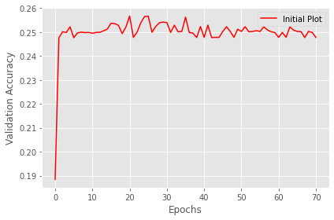

```python
print_result(nn,X_train,y_train,X_test,y_test,title="Initial Plot",color="red")
```

```python
print('Convergence:',(max(nn.val_score_[10:])-min(nn.val_score_[70:]))*100)
```

```
Convergence: 0.893839383938394
```

Now normalize the continuous numeric feature data. Use the example two-layer perceptron network from the class example and quantify performance using accuracy. Be sure that training converges by graphing the loss function versus the number of epochs.

We will now normalize the atribbutes, except the TrackId and State:

```python
atrib=df.columns
atrib=pd.Index.tolist(atrib)
del atrib[0]
print(atrib)
```

```
['TotalPop', 'Men', 'Women', 'Hispanic', 'White', 'Black', 'Native', 'Asian', 'Pacific', 'VotingAgeCitizen', 'Income', 'IncomeErr', 'IncomePerCap', 'IncomePerCapErr', 'Poverty', 'Professional', 'Service', 'Office', 'Construction', 'Production', 'Drive', 'Carpool', 'Transit', 'Walk', 'OtherTransp', '…
```

```python
for i in atrib:
    X_train[:,df.columns.get_loc(i)]=((X_train[:,df.columns.get_loc(i)]-np.mean(X_train[:,df.columns.get_loc(i)]))/np.std(X_train[:,df.columns.get_loc(i)]))
    X_test[:,df.columns.get_loc(i)]=(X_test[:,df.columns.get_loc(i)]-np.mean(X_test[:,df.columns.get_loc(i)]))/np.std(X_test[:,df.columns.get_loc(i)])
```

```python
vals['epochs']=200
nn = TLPBetterInitial(**vals)

nn.fit(X_train, y_train, print_progress=10)
yhat = nn.predict(X_test)
print('Accuracy:',accuracy_score(y_test,yhat))
```

```
Epoch: 200/200
```

```
Accuracy: 0.5451732673267327
```

```
=================
Normalized :
Resubstitution acc: 0.547993949186922
Validation acc: 0.5451732673267327
```

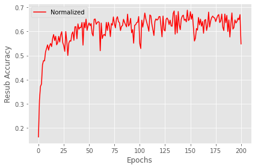

```python
print_result(nn,X_train,y_train,X_test,y_test,title="Normalized",color="red")
```

```python
print('Convergence:',(max(nn.score_[125:])-min(nn.score_[125:]))*100)
```

```
Convergence: 13.954687661154463
```

Now normalize the continuous numeric feature data AND one hot encode the categorical data. Use the example two-layer perceptron network from the class example and quantify performance using accuracy. Be sure that training converges by graphing the loss function versus the number of epochs.

```python
#y=pd.get_dummies(y)
tmp=pd.get_dummies(df.State,prefix='State')
df=pd.concat((df,tmp),axis=1)
del df['State']
```

```python
df.head()
```

|  | TotalPop | Men | Women | Hispanic | White | Black | Native | Asian | Pacific | VotingAgeCitizen | ... | State_42 | State_43 | State_44 | State_45 | State_46 | State_47 | State_48 | State_49 | State_50 | State_51 |
| --- | --- | --- | --- | --- | --- | --- | --- | --- | --- | --- | --- | --- | --- | --- | --- | --- | --- | --- | --- | --- | --- |
| 0 | 1845 | 899 | 946 | 2.4 | 86.3 | 5.2 | 0.0 | 1.2 | 0.0 | 1407 | ... | 0 | 0 | 0 | 0 | 0 | 0 | 0 | 0 | 0 | 0 |
| 1 | 2172 | 1167 | 1005 | 1.1 | 41.6 | 54.5 | 0.0 | 1.0 | 0.0 | 1652 | ... | 0 | 0 | 0 | 0 | 0 | 0 | 0 | 0 | 0 | 0 |
| 2 | 3385 | 1533 | 1852 | 8.0 | 61.4 | 26.5 | 0.6 | 0.7 | 0.4 | 2480 | ... | 0 | 0 | 0 | 0 | 0 | 0 | 0 | 0 | 0 | 0 |
| 3 | 4267 | 2001 | 2266 | 9.6 | 80.3 | 7.1 | 0.5 | 0.2 | 0.0 | 3257 | ... | 0 | 0 | 0 | 0 | 0 | 0 | 0 | 0 | 0 | 0 |
| 4 | 9965 | 5054 | 4911 | 0.9 | 77.5 | 16.4 | 0.0 | 3.1 | 0.0 | 7229 | ... | 0 | 0 | 0 | 0 | 0 | 0 | 0 | 0 | 0 | 0 |

5 rows × 85 columns

```python
y
```

```
array([2, 3, 2, ..., 3, 3, 3])
```

```python
X=df.to_numpy()
X_train, X_test, y_train, y_test = train_test_split(X,y,test_size = 0.2)
print(X_train.shape)
print(y_train.shape)
print(X_test.shape)
print(y_test.shape)
```

```
(58174, 85)
(58174,)
(14544, 85)
(14544,)
```

```python
atrib=df.columns
atrib=pd.Index.tolist(atrib)
print(atrib)
```

```
['TotalPop', 'Men', 'Women', 'Hispanic', 'White', 'Black', 'Native', 'Asian', 'Pacific', 'VotingAgeCitizen', 'Income', 'IncomeErr', 'IncomePerCap', 'IncomePerCapErr', 'Poverty', 'Professional', 'Service', 'Office', 'Construction', 'Production', 'Drive', 'Carpool', 'Transit', 'Walk', 'OtherTransp', '…
```

```python
df.columns.get_loc('State_0')
del atrib[df.columns.get_loc('State_0'):]
print(atrib)
```

```
['TotalPop', 'Men', 'Women', 'Hispanic', 'White', 'Black', 'Native', 'Asian', 'Pacific', 'VotingAgeCitizen', 'Income', 'IncomeErr', 'IncomePerCap', 'IncomePerCapErr', 'Poverty', 'Professional', 'Service', 'Office', 'Construction', 'Production', 'Drive', 'Carpool', 'Transit', 'Walk', 'OtherTransp', '…
```

```python
for i in atrib:
    X_train[:,df.columns.get_loc(i)]=((X_train[:,df.columns.get_loc(i)]-np.mean(X_train[:,df.columns.get_loc(i)]))/np.std(X_train[:,df.columns.get_loc(i)]))
    X_test[:,df.columns.get_loc(i)]=(X_test[:,df.columns.get_loc(i)]-np.mean(X_test[:,df.columns.get_loc(i)]))/np.std(X_test[:,df.columns.get_loc(i)])
```

```python
vals['epochs']=100
nn = TLPBetterInitial(**vals)

nn.fit(X_train, y_train, print_progress=10)
yhat = nn.predict(X_test)
print('Accuracy:',accuracy_score(y_test,yhat))
```

```
Epoch: 100/100
```

```
Accuracy: 0.7333608360836084
```

```
=================
Normalized+One-hot-encoded :
Resubstitution acc: 0.7408464262385258
Validation acc: 0.7333608360836084
```

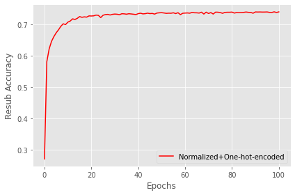

```python
print_result(nn,X_train,y_train,X_test,y_test,title="Normalized+One-hot-encoded",color="red")
```

```python
print('Convergence:',(max(nn.score_[30:])-min(nn.score_[30:]))*100)
```

```
Convergence: 0.923092790593738
```

Now we have better convergence and accuracy.

Compare the performance of the three models you just trained. Are there any meaningful differences in performance? Explain, in your own words, why these models have (or do not have) different performances.

As we previously mentioned, the addition of normalization and, after that, the one-hot-encode improved our accuracy. However, for a statistical result, it should be mentioned that, although the inclusion of normalization lead to a higher accuracy, it was not well converged, even with a larger number of epochs. One can notice the noise in the plot. With respect to the third model, the one with both normalization and one-hot-encoded, an accuracy of 73%, convergenged within a threshold of 0.9% was achieve. This illustrates the need to have a normalized data, as well as the appropriate type of discrete attributes.

### Modeling

Add support for a third layer in the multi-layer perceptron. Add support for saving (and plotting after training is completed) the average magnitude of the gradient for each layer, for each epoch. For magnitude calculation, you are free to use either the average absolute values or the L1/L2 norm. Quantify the performance of the model and graph the magnitudes for each layer versus the number of epochs.

In order to add the third layer, we need to update the following functions

- Initialize weights
- Get gradient
- Cost
- Fit
- L2 regression
- Feed forward
- Predict

So that we can now include the third layer (A3,W3,Z3)

```python
class ThreeLayerPerceptron(TLPBetterInitial):
    def __init__(self, n_hidden2=20, **kwds):
        # need to add to the original initializer
        self.n_hidden2 = n_hidden2
        # but keep other keywords
        super().__init__(**kwds)

    def _initialize_weights(self):
        """Initialize weights Glorot and He normalization."""
        #n_hidden2=self.n_hidden-2
        init_bound = 4*np.sqrt(6. / (self.n_hidden + self.n_features_ + 1))
        W1 = np.random.uniform(-init_bound, init_bound,(self.n_hidden, self.n_features_ + 1))
        W1[:,:1] = 0

        # reduce the final layer magnitude in order to balance the size of the gradients
        # between
        init_bound = 4*np.sqrt(6 / (self.n_hidden2 + self.n_hidden + 2))
        W2 = np.random.uniform(-init_bound, init_bound,(self.n_hidden2 + 1, self.n_hidden + 1))
        W2[:,:1] = 0


        init_bound = 4*np.sqrt(6 / (self.n_output_ + self.n_hidden2 + 1))
        W3 = np.random.uniform(-init_bound, init_bound,(self.n_output_, self.n_hidden2 + 1))
        W3[:,:1] = 0

        return W1, W2, W3


    def L2_reg(_,lambda_, W1, W2, W3):
        """Compute L2-regularization cost"""
        # only compute for non-bias terms
        return (lambda_/2.0)*np.sqrt(np.mean(W1[:, 1:]**2)+np.mean(W2[:, 1:]**2)+np.mean(W3[:, 1:]**2))


    def _cost(self,A4,Y_enc,W1,W2,W3):
        '''Get the objective function value'''
        cost = -np.mean(np.nan_to_num((Y_enc*np.log(A4)+(1-Y_enc)*np.log(1-A4))))
        L2_term = self.L2_reg(self.l2_C, W1 ,W2 ,W3)
        return cost + L2_term


    def _feedforward(self, X, W1, W2, W3):
        """Compute feedforward step        """
        A1 = self._add_bias_unit(X, how='column')
        A1 = A1.T
        Z1 = W1 @ A1
        A2 = self._sigmoid(Z1)
        A2 = self._add_bias_unit(A2, how='row')
        Z2 = W2 @ A2
        A3 = self._sigmoid(Z2)
        A3 = self._add_bias_unit(A3, how='row')
        Z3 = W3 @ A3
        A4 = self._sigmoid(Z3)
        return A1, Z1, A2, Z2, A3, Z3, A4


    def _get_gradient(self, A1, A2, A3, A4, Z1, Z2, Z3, Y_enc, W1, W2, W3):
        """ Compute gradient step using backpropagation.        """
        # vectorized backpropagation
        V3 = (A4-Y_enc) # <- this is only line that changed
        V2 = A3*(1-A3)*(W3.T @ V3)
        V1 = A2*(1-A2)*(W2.T @ V2)

        grad3 = V3 @ A3.T
        grad2 = V2 @ A2.T
        grad1 = V1[1:,:] @ A1.T

        # regularize weights that are not bias terms
        grad1[:, 1:] += W1[:, 1:] * self.l2_C
        grad2[:, 1:] += W2[:, 1:] * self.l2_C
        grad3[:, 1:] += W3[:, 1:] * self.l2_C

        return grad1, grad2, grad3


    def fit(self, X, y, print_progress=False, XY_test=None):
        """ Learn weights from trainin        cost = Y_encg data. With mini-batch"""
        X_data, y_data = X.copy(), y.copy()
        Y_enc = self._encode_labels(y)

        # init weights and setup matrices
        self.n_features_ = X_data.shape[1]
        self.n_output_ = Y_enc.shape[0]
        self.W1, self.W2, self.W3 = self._initialize_weights()

        rho_W1_prev = np.zeros(self.W1.shape)
        rho_W2_prev = np.zeros(self.W2.shape)
        rho_W3_prev = np.zeros(self.W3.shape)

        self.cost_ = []
        self.score_ = []
        # get starting acc@staticmethod
        self.score_.append(accuracy_score(y_data,self.predict(X_data)))
        # keep track of validation, if given
        if XY_test is not None:
            X_test = XY_test[0].copy()
            y_test = XY_test[1].copy()
            self.val_score_ = []
            self.val_score_.append(accuracy_score(y_test,self.predict(X_test)))

        for i in range(self.epochs):

            # adaptive learning rate
            # \frac{\eta}{1+\epsilon\cdot k}
            eta = self.eta / (1 + self.decrease_const*i)

            if print_progress>0 and (i+1)%print_progress==0:
                sys.stderr.write('\rEpoch: %d/%d' % (i+1, self.epochs))
                sys.stderr.flush()

            if self.shuffle:
                idx_shuffle = np.random.permutation(y_data.shape[0])
                X_data, Y_enc, y_data = X_data[idx_shuffle], Y_enc[:, idx_shuffle], y_data[idx_shuffle]

            mini = np.array_split(range(y_data.shape[0]), self.minibatches)
            mini_cost = []
            for idx in mini:

                # feedforward
                A1, Z1, A2, Z2, A3, Z3, A4 = self._feedforward(X_data[idx],
                                                               self.W1,
                                                               self.W2,
                                                               self.W3)

                cost = self._cost(A4,Y_enc[:, idx],self.W1,self.W2,self.W3)
                mini_cost.append(cost) # this appends cost of mini-batch only
                # compute gradient via backpropagation
                grad1, grad2, grad3 = self._get_gradient(A1=A1, A2=A2, A3=A3, A4=A4, Z1=Z1, Z2=Z2, Z3=Z3,
                                                  Y_enc=Y_enc[:, idx],
                                                  W1=self.W1,W2=self.W2,W3=self.W3)

                # momentum calculations
                rho_W1, rho_W2, rho_W3 = eta * grad1, eta * grad2, eta * grad3
                self.W1 -= (rho_W1 + (self.alpha * rho_W1_prev))
                self.W2 -= (rho_W2 + (self.alpha * rho_W2_prev))
                self.W3 -= (rho_W3 + (self.alpha * rho_W3_prev))
                rho_W1_prev, rho_W2_prev, rho_W3_prev = rho_W1, rho_W2, rho_W3

            self.cost_.append(mini_cost)
            self.score_.append(accuracy_score(y_data,self.predict(X_data)))
            if XY_test is not None:
                self.val_score_.append(accuracy_score(y_test,self.predict(X_test)))

        return self


    def predict(self, X):
        """Predict class labels"""
        _, _, _, _, _, _, A4 = self._feedforward(X, self.W1, self.W2, self.W3)
        y_pred = np.argmax(A4, axis=0)
        return y_pred
```

```python
vals = { 'n_hidden':30, 'n_hidden2':25,
         'C':0.1, 'epochs':100, 'eta':0.001,
         'alpha':0.001, 'decrease_const':1e-5, 'minibatches':50,
         'shuffle':True,'random_state':1}
```

```python
vals['epochs']=100
nn = ThreeLayerPerceptron(**vals)
nn.fit(X_train, y_train, print_progress=10)
```

[output not shown]

```python
yhat = nn.predict(X_test)
print('Accuracy:',accuracy_score(y_test,yhat))
```

[output not shown]

```python
print_result(nn,X_train,y_train,X_test,y_test,title="Normalized+One-hot-encoded",color="red")
```

[output not shown]

```python
print('Convergence:',(max(nn.score_[30:])-min(nn.score_[30:]))*100)
```

[output not shown]

Repeat the previous step, adding support for a fourth layer.

Repeat the previous step, adding support for a fifth layer.

Implement an adaptive learning technique that was discussed in lecture and use it on the five layer network. Compare the performance of this model with and without the adaptive learning strategy. Do not use AdaM for the adaptive learning technique.

### Exceptional Work

Implement adaptive momentum (AdaM) in the five layer neural network and quantify the performance.